# Categorical Composition

EdgeBasedModels.jl Vignette 12

Author

Simon Frost

Published

May 16, 2026

## Introduction

Epidemiological models are often built by combining simpler pieces — two populations coupled by travel, or a base model stratified by age. **Categorical composition** gives this idea a formal algebraic backbone. Each submodel is an *open system* with typed *ports* that can be wired together. The wiring determines how infection pressure flows between components, and a *functor* maps the resulting network description to a concrete ODE system.

Key benefits:

1. **Composability** — build complex multi-population models from reusable parts.
2. **Formal guarantees** — the functor preserves composition, so the combined ODE faithfully represents the wired network.
3. **Natural transformations** — relate EBCM network models to simpler mass-action approximations and quantify the difference.

## Setup

```julia
using EdgeBasedModels
using ModelingToolkit
using OrdinaryDiffEq
using Plots
```

## Open systems and ports

An `OpenEBCM` wraps an edge-based compartmental model together with named **ports** — typed boundary interfaces through which systems can interact. Convenience constructors `open_sir` and `open_seir` create open systems directly from a PGF and rate parameters.

```julia
pgf_a = poisson_pgf(5.0)
m_sir = open_sir(pgf_a, 1/6, 0.25; name = :pop_a)
```

```
OpenEBCM(:pop_a, StaticConfigurationModel(DegreePGF(z, exp(5.0(-1 + z))), DiseaseProgression(:S, :I, DiseaseStage[DiseaseStage(:I, 0.16666666666666666), DiseaseStage(:R, 0)], DiseaseTransition[DiseaseTransition(:I, :R, 0.25)])), Port[Port(:S, :susceptible), Port(:I, :infectious), Port(:R, :recovered…
```

Each port has a name and a type (`:susceptible`, `:infectious`, or `:recovered`):

```julia
for p in m_sir.ports
    println("  Port $(p.name) — type $(p.type)")
end
```

```
  Port S — type susceptible
  Port I — type infectious
  Port R — type recovered
```

An SEIR model has four ports (S, E, I, R), where the exposed and recovered stages are both non-infectious:

```julia
m_seir = open_seir(pgf_a, 0.25, 1/6, 0.25; name = :seir)
println("SEIR ports: ", length(m_seir.ports))
for p in m_seir.ports
    println("  Port $(p.name) — type $(p.type)")
end
```

```
SEIR ports: 4
  Port S — type susceptible
  Port E — type latent
  Port I — type infectious
  Port R — type recovered
```

## Tensor product — independent populations

The tensor product $m_1 \otimes m_2$ places two open systems side by side with **no interaction**. Each component evolves independently, giving block-diagonal dynamics.

```julia
pgf_b = poisson_pgf(3.0)
m1 = open_sir(pgf_a, 1/6, 0.25; name = :pop_a)
m2 = open_sir(pgf_b, 1/6, 0.25; name = :pop_b)

tp = tensor(m1, m2)
println("Tensor product ports: ", length(tp.ports))
```

```
Tensor product ports: 6
```

Build the ODE system and solve:

```julia
sys_tp = build_edge_system(tp.model)
ic_tp = default_initial_conditions(sys_tp; seed_fraction = 0.01)
prob_tp = ODEProblem(sys_tp.system, ic_tp, (0.0, 40.0))
sol_tp = solve(prob_tp; abstol = 1e-8, reltol = 1e-8)
```

[output not shown]

We can also solve each population in isolation and confirm the tensor product does not alter trajectories:

```julia
sys_a = build_edge_system(m1.model)
ic_a = default_initial_conditions(sys_a; seed_fraction = 0.01)
sol_a = solve(ODEProblem(sys_a.system, ic_a, (0.0, 40.0)); abstol = 1e-8, reltol = 1e-8)

sys_b = build_edge_system(m2.model)
ic_b = default_initial_conditions(sys_b; seed_fraction = 0.01)
sol_b = solve(ODEProblem(sys_b.system, ic_b, (0.0, 40.0)); abstol = 1e-8, reltol = 1e-8)
```

[output not shown]

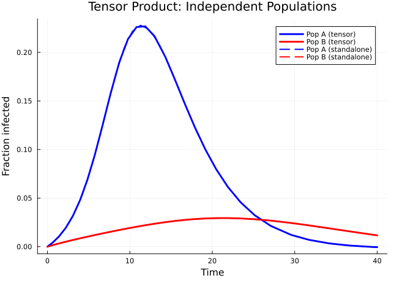

Figure 1: Tensor product: two independent SIR populations evolve without interaction.

```julia
# Extract S = ψ(θ) for each population
κ_a, κ_b = 5.0, 3.0
ψ_a(x) = exp(κ_a * (x - 1))
ψ_b(x) = exp(κ_b * (x - 1))

# Tensor system
θ_a_tp = compartment(sol_tp, sys_tp, :θ_pop_a)
θ_b_tp = compartment(sol_tp, sys_tp, :θ_pop_b)
R_a_tp = compartment(sol_tp, sys_tp, :R_pop_a)
R_b_tp = compartment(sol_tp, sys_tp, :R_pop_b)
S_a_tp = ψ_a.(θ_a_tp)
S_b_tp = ψ_b.(θ_b_tp)
I_a_tp = 1.0 .- S_a_tp .- R_a_tp
I_b_tp = 1.0 .- S_b_tp .- R_b_tp

# Standalone systems
θ_a_solo = compartment(sol_a, sys_a, :θ)
R_a_solo = compartment(sol_a, sys_a, :R)
S_a_solo = ψ_a.(θ_a_solo)
I_a_solo = 1.0 .- S_a_solo .- R_a_solo

θ_b_solo = compartment(sol_b, sys_b, :θ)
R_b_solo = compartment(sol_b, sys_b, :R)
S_b_solo = ψ_b.(θ_b_solo)
I_b_solo = 1.0 .- S_b_solo .- R_b_solo

plot(sol_tp.t, I_a_tp, label = "Pop A (tensor)", lw = 3, color = :blue)
plot!(sol_tp.t, I_b_tp, label = "Pop B (tensor)", lw = 3, color = :red)
plot!(sol_a.t, I_a_solo, label = "Pop A (standalone)", lw = 2, ls = :dash, color = :blue)
plot!(sol_b.t, I_b_solo, label = "Pop B (standalone)", lw = 2, ls = :dash, color = :red)
xlabel!("Time")
ylabel!("Fraction infected")
title!("Tensor Product: Independent Populations")
```

The solid (tensor) and dashed (standalone) curves overlap perfectly — the tensor product preserves each component’s dynamics.

## Composition via wiring — current limitations

The `compose` combinator records port wiring at the categorical level, but `build_edge_system` does not yet emit a coupled ODE system from a `ComposedModel` whose wiring is non-empty: it raises an `ArgumentError` because injecting cross-system transmission pressure requires extra closure assumptions that have not been formalised in the package. The wiring metadata is still useful for bookkeeping and for downstream tools.

```julia
m_city  = open_sir(pgf_a, 1/6, 0.25; name = :city)
m_rural = open_sir(pgf_b, 1/6, 0.25; name = :rural)

# Wire city's infectious port (I) to rural's susceptible port (S)
cp = EdgeBasedModels.compose(m_city, m_rural, [:I => :S])
println("Composed ports: ", length(cp.ports))
for p in cp.ports
    println("  Port $(p.name) — type $(p.type)")
end
```

```
Composed ports: 4
  Port city_S — type susceptible
  Port city_R — type recovered
  Port rural_I — type infectious
  Port rural_R — type recovered
```

Notice that the wired ports (`:I` from city, `:S` from rural) are consumed — only the remaining boundary ports appear.

```julia
# Confirm that wired composition is rejected by the ODE builder
try
    build_edge_system(cp.model)
catch err
    println(typeof(err), ": ", err.msg)
end
```

```
ArgumentError: cross-system wiring is not yet supported by build_edge_system; use tensor(...) for independent composition or stratify/multi-type models for coupled populations
```

To couple two populations dynamically, use `stratify` (below) or build a `MultiTypeConfigurationModel` directly — both produce fully coupled ODE systems.

## Stratification — age-structured populations

`stratify` crosses a base model with population strata. Given a base SIR on a Poisson network and a row-stochastic mixing matrix, it creates a `MultiTypeConfigurationModel` internally.

```julia
pgf_base = poisson_pgf(5.0)
base = open_sir(pgf_base, 1/6, 0.25; name = :base)

# Two age groups with assortative mixing
mixing = [0.7 0.3;
          0.3 0.7]
strat = stratify(base, [:young, :old], mixing)
println("Stratified ports: ", length(strat.ports))
```

```
Stratified ports: 6
```

```julia
sys_strat = build_edge_system(strat.model)
ic_strat = default_initial_conditions(sys_strat; seed_fraction = 0.01)
prob_strat = ODEProblem(sys_strat.system, ic_strat, (0.0, 40.0))
sol_strat = solve(prob_strat; abstol = 1e-8, reltol = 1e-8)
```

[output not shown]

[output cut: 15 more lines]

With $K=2$ types and $M=2$ stages (I, R), the multi-type system has $K^2(1+M)+K M = 16$ equations:

```julia
n_eqs = length(ModelingToolkit.equations(sys_strat.system))
println("Number of equations: $n_eqs")
```

```
Number of equations: 16
```

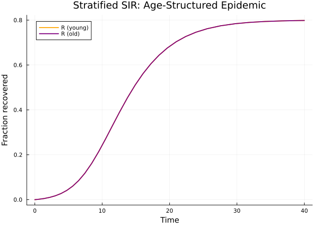

Figure 2: Stratified SIR: young and old populations with assortative contact mixing.

```julia
R_young = compartment(sol_strat, sys_strat, :R_young)
R_old   = compartment(sol_strat, sys_strat, :R_old)

plot(sol_strat.t, R_young, label = "R (young)", lw = 2, color = :orange)
plot!(sol_strat.t, R_old,  label = "R (old)",   lw = 2, color = :purple)
xlabel!("Time")
ylabel!("Fraction recovered")
title!("Stratified SIR: Age-Structured Epidemic")
```

## Natural transformations — EBCM to mass-action

A **natural transformation** relates the EBCM network model to a simpler mass-action approximation. On a Poisson network the excess degree distribution equals the degree distribution, so the EBCM and mass-action SIR are closely related. The `to_mass_action` function extracts $\beta_\text{eff} = \beta \cdot \psi''(1)/\psi'(1)$ (the excess-degree ratio, *not* the mean degree) and $\gamma$. For a Poisson network this ratio equals $\langle k \rangle$, but for non-Poisson networks the two differ.

```julia
pgf_poisson = poisson_pgf(5.0)
prog_sir = DiseaseProgression(
    [DiseaseStage(:I; transmission_rate = 1/6),
     DiseaseStage(:R; transmission_rate = 0)],
    [DiseaseTransition(:I, :R, 0.25)]; entry = :I,
)
sir_model = StaticConfigurationModel(pgf_poisson, prog_sir)

ma = to_mass_action(sir_model)
println("β_eff = ", ma.β_eff, "  (expected: (1/6) × 5 ≈ 0.833)")
println("γ     = ", ma.γ)
```

```
β_eff = 0.8333333333333333  (expected: (1/6) × 5 ≈ 0.833)
γ     = 0.25
```

The `compare_models` function solves both the EBCM and the mass-action approximation and returns the solutions for direct comparison:

```julia
result = compare_models(sir_model; tspan = (0.0, 40.0), ε = 0.01)
println("β_eff = ", result.β_eff)
println("γ     = ", result.γ)
```

```
β_eff = 0.8333333333333333
γ     = 0.25
```

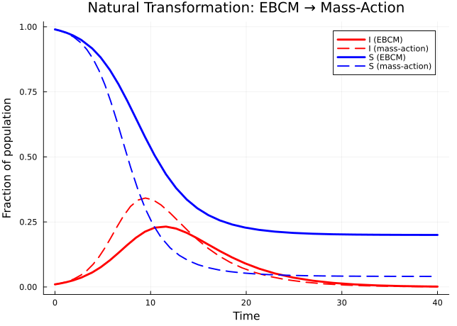

Figure 3: EBCM vs mass-action approximation on a Poisson(5) network.

```julia
# EBCM solution
S_ebcm = compartment(result.ebcm, result.ebcm_system, :S)
I_ebcm = compartment(result.ebcm, result.ebcm_system, :I)

# Mass-action solution
S_ma = result.mass_action[result.ma_vars.S]
I_ma = result.mass_action[result.ma_vars.I]

plot(result.ebcm.t, I_ebcm, label = "I (EBCM)", lw = 3, color = :red)
plot!(result.mass_action.t, I_ma, label = "I (mass-action)", lw = 2, ls = :dash, color = :red)
plot!(result.ebcm.t, S_ebcm, label = "S (EBCM)", lw = 3, color = :blue)
plot!(result.mass_action.t, S_ma, label = "S (mass-action)", lw = 2, ls = :dash, color = :blue)
xlabel!("Time")
ylabel!("Fraction of population")
title!("Natural Transformation: EBCM → Mass-Action")
```

We can record the natural transformation as metadata:

```julia
nt = NaturalTransformation(
    :ebcm_to_mass_action,
    StaticConfigurationModel,
    Nothing,
    "EBCM → mass-action; valid when network is Poisson",
)
println("Transform: ", nt.name, " (", nt.source_type, " → ", nt.target_type, ")")
println("  ", nt.description)
```

```
Transform: ebcm_to_mass_action (StaticConfigurationModel → Nothing)
  EBCM → mass-action; valid when network is Poisson
```

## Functor and functoriality

The `EBCMFunctor` is a callable that maps an open system (in the network category) to an `EdgeModelSystem` (in the ODE category) via `build_edge_system`. Categorically, a functor must preserve composition:

$$F(m_1 \otimes m_2) \cong F(m_1) \otimes F(m_2)$$

meaning the ODE system obtained by first composing and then applying $F$ should match the one obtained by applying $F$ to each component and then combining.

```julia
F = EBCMFunctor(:F)

# Apply functor to a single open system
sys_single = F(m1)
println("Variables: ", keys(sys_single.variables))
println("Observables: ", keys(sys_single.observables))
```

```
Variables: [:R, :φ_I, :pop_I, :pop_R, :φ_R, :θ]
Observables: [:I, :φ_S, :S, :edge_hazard, :excess_hazard]
```

```julia
ic_single = default_initial_conditions(sys_single; seed_fraction = 0.01)
sol_single = solve(ODEProblem(sys_single.system, ic_single, (0.0, 40.0));
                   abstol = 1e-8, reltol = 1e-8)
println("Final S = ", compartment(sol_single, sys_single, :S)[end])
```

```
Final S = 0.19997795887982375
```

### Verifying functoriality

`verify_functoriality` checks the functor equation by solving both paths — compose-then-map vs map-then-combine — and comparing the trajectories:

```julia
m_fa = open_sir(pgf_a, 1/6, 0.25; name = :fa)
m_fb = open_sir(pgf_b, 1/6, 0.25; name = :fb)

vf = verify_functoriality(m_fa, m_fb, Pair{Symbol,Symbol}[];
                           tspan = (0.0, 40.0), atol = 1e-4)
println("Is functorial: ", vf.is_functorial)
println("Max trajectory difference: ", vf.max_difference)
println("Composed retcode: ", vf.composed_retcode)
```

```
Is functorial: true
Max trajectory difference: 1.3863654668710979e-10
Composed retcode: Success
```

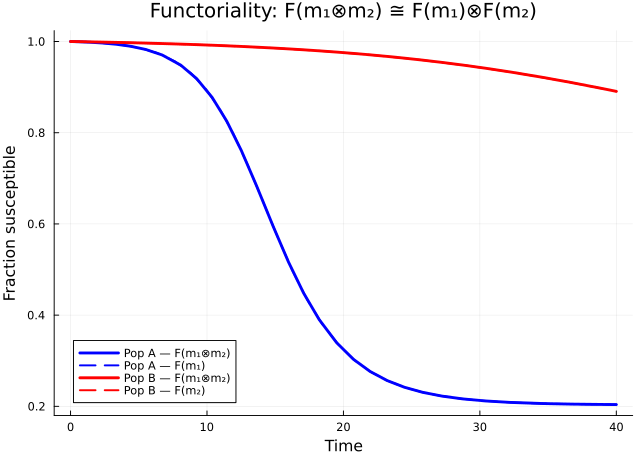

Figure 4: Functoriality check: F(m₁⊗m₂) matches F(m₁),F(m₂) to machine precision.

```julia
# Build systems for correct variable keys
sys_fab = build_edge_system(tensor(m_fa, m_fb).model)
sys_fa = build_edge_system(m_fa.model)
sys_fb = build_edge_system(m_fb.model)

κ_fa, κ_fb = 5.0, 3.0
ψ_fa(x) = exp(κ_fa * (x - 1))
ψ_fb(x) = exp(κ_fb * (x - 1))

θ1_comp = compartment(vf.composed_solution, sys_fab, :θ_fa)
θ2_comp = compartment(vf.composed_solution, sys_fab, :θ_fb)
S1_comp = ψ_fa.(θ1_comp)
S2_comp = ψ_fb.(θ2_comp)

θ1_ind = compartment(vf.individual_solutions[1], sys_fa, :θ)
θ2_ind = compartment(vf.individual_solutions[2], sys_fb, :θ)
S1_ind = ψ_fa.(θ1_ind)
S2_ind = ψ_fb.(θ2_ind)

plot(vf.composed_solution.t, S1_comp, label = "Pop A — F(m₁⊗m₂)", lw = 3, color = :blue)
plot!(vf.individual_solutions[1].t, S1_ind, label = "Pop A — F(m₁)", lw = 2, ls = :dash, color = :blue)
plot!(vf.composed_solution.t, S2_comp, label = "Pop B — F(m₁⊗m₂)", lw = 3, color = :red)
plot!(vf.individual_solutions[2].t, S2_ind, label = "Pop B — F(m₂)", lw = 2, ls = :dash, color = :red)
xlabel!("Time")
ylabel!("Fraction susceptible")
title!("Functoriality: F(m₁⊗m₂) ≅ F(m₁)⊗F(m₂)")
```

The solid (composed) and dashed (individual) curves coincide, confirming that the EBCM functor preserves the tensor product.

## Simulation validation

We validate the EBCM SIR prediction (Poisson κ=5) used in the natural-transformation section against Gillespie SSA via `NetworkOutbreaks.jl`.

```julia
include("../_validation.jl")

import EdgeBasedModels: sir_model as ebm_sir_model
prog_for_no = ebm_sir_model()  # avoids local `sir_model` rebinding above

t_g, μ_g, σ_g = gillespie_ribbon(
    prog_for_no, Dict(:β => 1/6, :γ => 0.25),
    poisson_graph_builder(1000, 5.0);
    N = 1000, n_graphs = 5, nsims_per_graph = 20,
    tspan = (0.0, 40.0), seed_fraction = 0.01)
```

```
([0.0, 0.5, 1.0, 1.5, 2.0, 2.5, 3.0, 3.5, 4.0, 4.5  …  35.5, 36.0, 36.5, 37.0, 37.5, 38.0, 38.5, 39.0, 39.5, 40.0], Dict(:I => [0.01, 0.01311, 0.01668, 0.02134, 0.02621, 0.03251, 0.03976, 0.04803, 0.057229999999999996, 0.06829  …  0.00431, 0.0038900000000000002, 0.00346, 0.00317, 0.00294, 0.00265, 0…
```

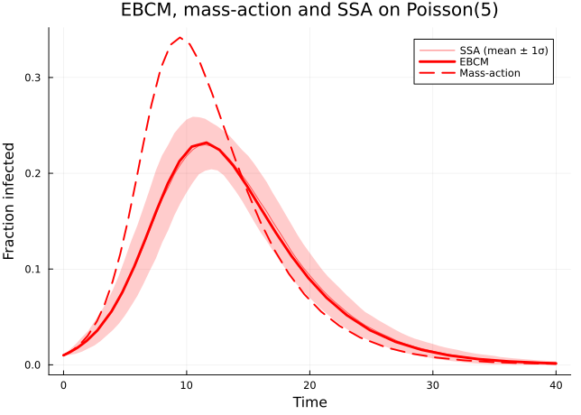

Figure 5: EBCM (red) and mass-action approximation (red dashed) versus Gillespie SSA mean ± 1σ (red ribbon).

```julia
plot(t_g, μ_g[:I], ribbon = σ_g[:I], label = "SSA (mean ± 1σ)",
     color = :red, fillalpha = 0.2, linealpha = 0.6)
plot!(result.ebcm.t, I_ebcm, label = "EBCM", lw = 3, color = :red)
plot!(result.mass_action.t, I_ma, label = "Mass-action", lw = 2,
      ls = :dash, color = :red)
xlabel!("Time"); ylabel!("Fraction infected")
title!("EBCM, mass-action and SSA on Poisson(5)")
```

The EBCM tracks the SSA mean closely; the mass-action curve diverges in the expected direction because it ignores the depletion of susceptible neighbours.

## Summary

[output not shown]